# Rest

Вывод: Из анализа данных видно. 1 - Существует некое равновесное состояние насыщения рынка. (1 кафе на 10000 населения города) С этой позиции перспективными являются города: Las Vegas, Miama, Portland. 2 - Наблюдается зависимость успешного закрепления на рынке и числа ресторанов.

Рекомендация: Расмотреть детально рынки Las Vegas, Miami, Portland, со стратегией открытия двух и более ресторанов в одном городе.

```python
import pandas as pd
import seaborn as sns
from matplotlib import pyplot as plt
import geopandas as gpd
import contextily as cx
```

```python
df_18 = pd.read_csv('2018.csv')
df_19 = pd.read_csv('2019.csv')
```

Объединяем таблицы с данными. Вводим дополнительные столбцы обновления данных. Отбираем данные по штатам. Сортируем по городам и групперуем по датам.

```python
# Список штатов.
states = ['OH', 'NV', 'FL', 'IN', 'AL', 'OR']
# Список городовю
city_to_select = ['Columbus',
                  'Cincinnati',
                  'Cleveland',
                  'Las Vegas',
                  'Miami',
                  'Indianapolis',
                  'Birmingham',
                  'Portland']
# Вводим маркеры для датафреймов 2018 и 2019г.
year = ['2018', '2019']
df_18['group'] = year[0]
df_19['group'] = year[1]
# Названия кафе приводим к одному регистру и убираем лишние символы
df_main = pd.concat([df_18,df_19]).reset_index(drop=1)
df_main['name'] = df_main['name'].apply(lambda x: x.lower().replace("'", "").replace(' ', '').replace('¬æ', ''))
# Отфильтровываем данные по штатам и городам.
df_filtred = df_main[(df_main['province'].isin(states))
                     & (df_main['city'].isin(city_to_select))].reset_index(drop=1)
df_filtred.loc[371, 'name'] = df_filtred['name'][371].split('-')[0]
# Групируем по названию кафе и городам. Получаем данные по числу кафе каждой компании в каждом городе.
df_grouped = (df_filtred
             .groupby(['group','city','name'])
             .agg(cnt=('name','count'))
             .sort_values(by=['city','cnt'], ascending=False)
             .reset_index()).copy()
```

Расчитываем среднее количество заведений на 10000 человек.

```python
# Добавляем к датафрейму данные населения городов (данные взяты с ресурса: www.opendatanetwork.com)
pop_18 = [867628, 300357, 387398, 626637, 451214, 857637, 212021, 639387]
pop_19 = [880301, 296778, 381663, 634307, 454851, 864276, 209857, 649431]
# Добавляем к датафрейму данные туристического потока городов
turism = [41900000, 26000000, 19600000, 49500000, 24200000, 29200000, 3900000, 12500000]
df_pop = pd.DataFrame(data={'city':city_to_select,
                             '2018':pop_18,
                             '2019':pop_19,
                             'tourism': turism})

# Групперуем по городам и датам. Получаем данные по общему числу кафе в каждом городе.
df_quant = (df_grouped.groupby(['group', 'city'])
                    .agg(quantity=('cnt','sum'))
                    .sort_values(by=['city','group','quantity'], ascending=True)
                    .reset_index())

# Добавляем колонки с населением и количеством кафе на 10К человек для каждого города.
for i in range(len(df_quant)):
    for j in range(len(df_pop)):
        if df_quant['city'][i] == df_pop['city'][j]:
            for q in range(len(df_pop.columns)):
                if df_quant['group'][i] == df_pop.columns[q]:
                    df_quant.loc[i,'population'] = int(df_pop[df_pop.columns[q]][j])
                    df_quant.loc[i,'cafe on 10K persons'] = round((df_quant['quantity'][i] *10000 / df_pop[df_pop.columns[q]][j] ), 2)
                    df_quant.loc[i,'10K person on cafe'] = round(df_pop[df_pop.columns[q]][j] / (df_quant['quantity'][i] *10000), 2)
                elif (df_quant['group'][i] == '2019') & (df_pop.columns[q] == 'tourism'):
                    df_quant.loc[i, '10K turist on cafe'] = round(df_pop[df_pop.columns[q]][j] / (df_quant['quantity'][i] *10000), 2)
df_quant['total'] = df_quant[df_quant['group'] == '2019']['10K person on cafe'] + df_quant[df_quant['group'] == '2019']['10K turist on cafe']

# Площать городов (km^2):
land_area = {'Portland': 375.81,
             'Las Vegas': 348.17,
             'Miami': 145.20,
             'Birmingham': 384.94,
             'Cincinnati': 204.59,
             'Cleveland': 213.59,
             'Columbus': 581.03,
             'Indianapolis': 953.18}

df_quant_19 = df_quant[df_quant.group == '2019'].reset_index(drop=1)
df_quant_19['area'] = 0

for i in list(land_area):
    for j in range(len(df_quant_19)):
        if (i == df_quant_19['city'][j]):
            df_quant_19.loc[j,'area'] = land_area[i]

df_quant_19['density'] = round(df_quant_19['area'] / df_quant_19['quantity'], 2)
```

Посмотрим изменение количества кафе за 2018 и 2019.

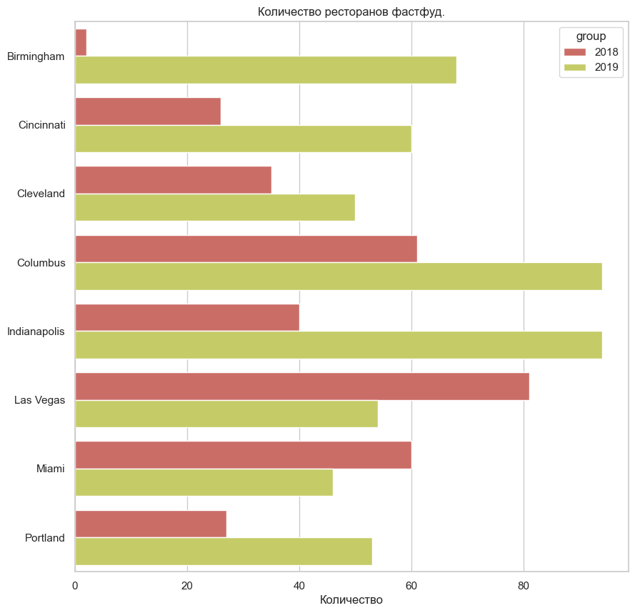

```python
plt.rcParams['figure.figsize'] = (10,10) #Размер графиков
sns.set_theme(style='whitegrid', palette='hls') # Цветовая настройка

sns.barplot(df_quant,
            x='quantity',
            y='city',
            hue='group',
            errorbar=None)

plt.title('Количество ресторанов фастфуд.')
plt.ylabel(None)
plt.xlabel('Количество')
plt.savefig('Количество ресторанов(динамика).pdf')
plt.show()
```

Из диаграммы видно, что в 6 городах количество кафе увеличилось, а в 2 уменьшилось.

Посмотрим распределение числа кафе на 10000 человек. (в разрезе за 2018 и 2019г)

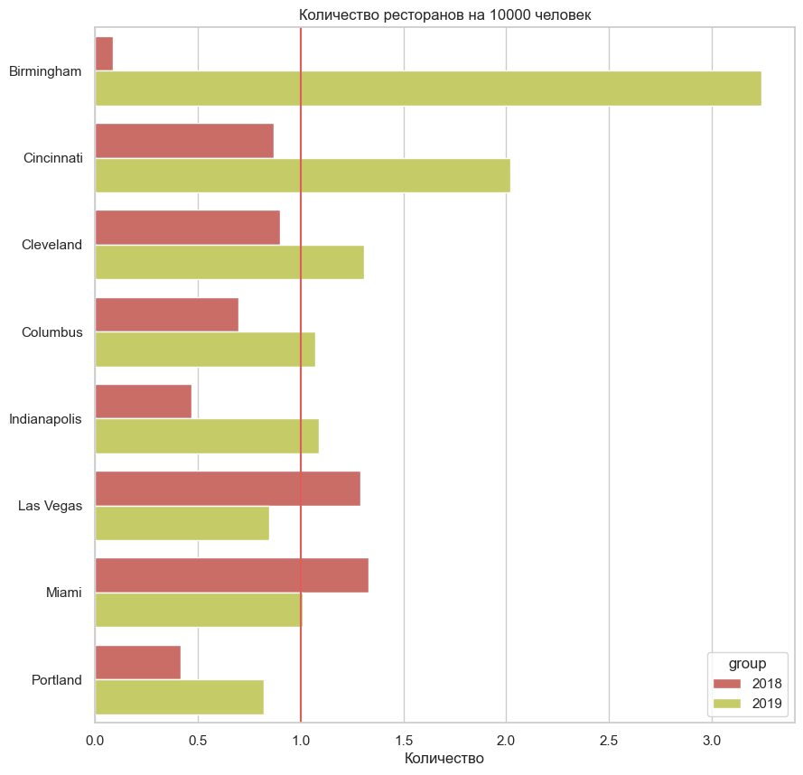

```python
sns.barplot(df_quant,
            x='cafe on 10K persons',
            y='city',
            hue='group',
            errorbar=None)

plt.axvline(x=1)

plt.title('Количество ресторанов на 10000 человек')
plt.xlabel('Количество')
plt.ylabel(None)
plt.savefig('Рестораны на 10К человек(динамика).pdf')
plt.show()
```

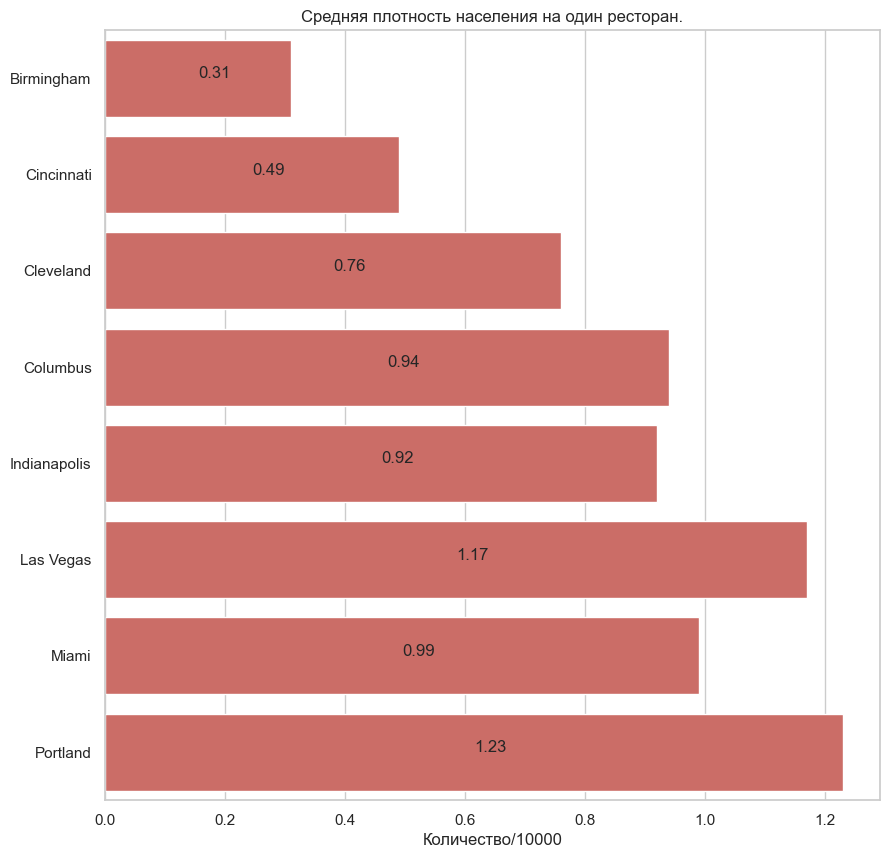

```python
sns.barplot(df_quant_19,
            x='10K person on cafe',
            y='city',
            errorbar=None)

for i in range(len(df_quant_19)):
    plt.text(x = df_quant_19['10K person on cafe'][i] / 2,
             y = i,
             s = str(df_quant_19['10K person on cafe'][i]))

plt.title('Средняя плотность населения на один ресторан.')
plt.xlabel('Количество/10000')
plt.ylabel(None)
plt.savefig('Плотность населения на один ресторан.pdf')
plt.show()
```

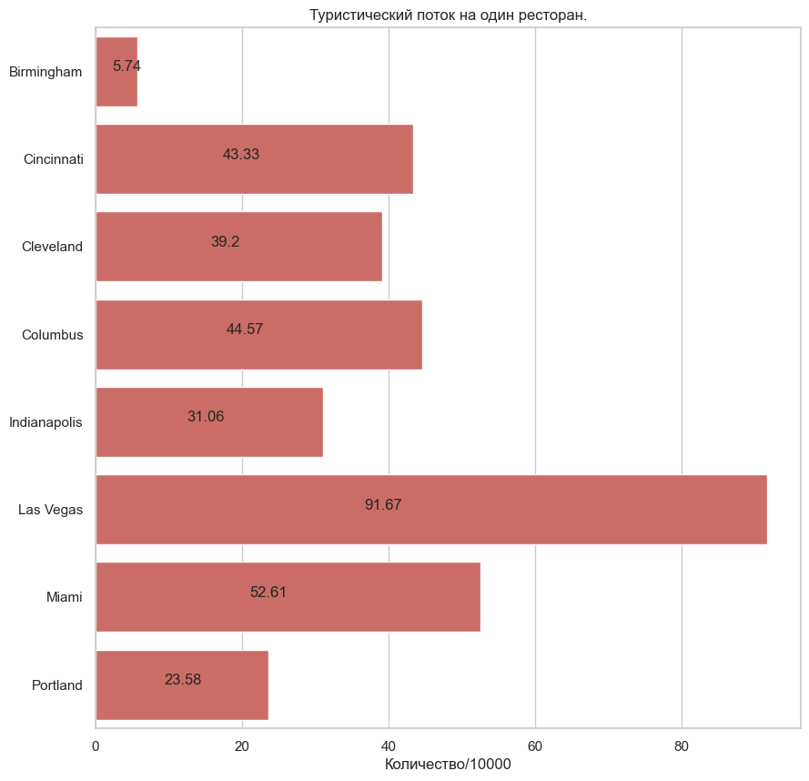

```python
sns.barplot(df_quant_19,
            x='10K turist on cafe',
            y='city',
            errorbar=None)

for i in range(len(df_quant_19)):
    plt.text(x = df_quant_19['10K turist on cafe'][i] / 2.5,
             y = i,
             s = str(df_quant_19['10K turist on cafe'][i]))

plt.title('Туристический поток на один ресторан.')
plt.xlabel('Количество/10000')
plt.ylabel(None)
plt.savefig('Плотность туристов на ресторан.pdf')
plt.show()
```

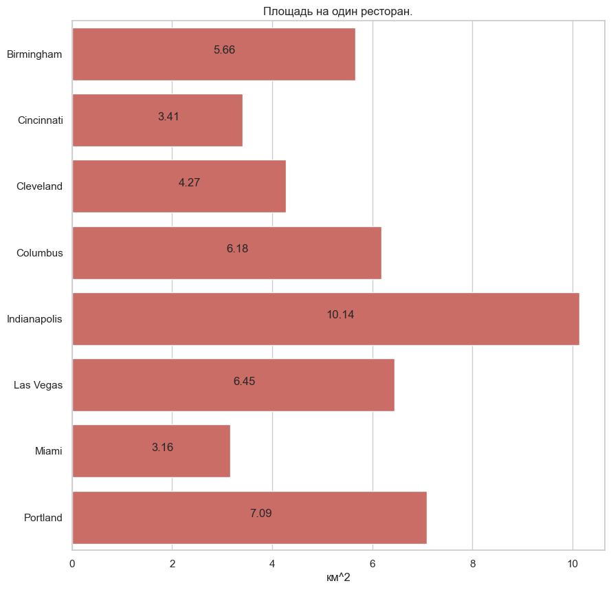

```python
sns.barplot(df_quant_19,
            x='density',
            y='city')
for i in range(len(df_quant_19)):
    plt.text(x = df_quant_19['density'][i] / 2,
             y = i,
             s = str(df_quant_19['density'][i]))

plt.title('Площадь на один ресторан.')
plt.xlabel('км^2')
plt.ylabel(None)
plt.savefig('Площадь на один ресторан .pdf')
```

Видно, что в городах где соотношение заведение на 10К человек < 1 в 2018 году произошло увеличение числа заведений в 2019г. В это же время при соотношении > 1 наблюдается снижение числа фастфудов.

Рост числа кафе в Бирмингеме в 2019г. выглядит очень анамально.

Если рассматривать плотность на 1 кафе, видно что больший вклад вносит туристический поток.

Посмотрим на компании, которые были открыты в 2018, но закрылись в 2019. и наоборот на вновь открытые. В каждом городе.

```python
# Количество компаний в городах в 18 и 19гг.
quant_in_city_18 = []
quant_in_city_19 = []
# Количество компании, которые были на рынке в 2018г, но не было 2019г.
close_in_city = []
# Количество компании, которые остались 2019г.
old_in_city = []
# Количество компании, которые появились на рынке 2019г.
open_new_in_city = []
# Количество ресторанов, которые были открыты или закрыты в городах.
open_in_city = []
# Список компаний которые закрылись.
close_in_city_list = []
# Список компаний которые открылись.
open_in_city_list = []
# Список компаний которые сохранили присутствие на рынке.
old_in_city_list = []

for i in city_to_select:
    quant_in_city_18.append(len(set(df_filtred[(df_filtred['group'] == '2018') & (df_filtred['city'] == i)]['name'])))

for i in city_to_select:
    quant_in_city_19.append(len(set(df_filtred[(df_filtred['group'] == '2019') & (df_filtred['city'] == i)]['name'])))

for i in city_to_select:
    close_in_city_list.append(list((set(df_filtred[(df_filtred['group'] == '2018') & (df_filtred['city'] == i)]['name'])
                              .difference(set(df_filtred[(df_filtred['group'] == '2019') & (df_filtred['city'] == i)]['name'])))))

for i in city_to_select:
    open_in_city_list.append(list((set(df_filtred[(df_filtred['group'] == '2019') & (df_filtred['city'] == i)]['name'])
                                 .difference(set(df_filtred[(df_filtred['group'] == '2018') & (df_filtred['city'] == i)]['name'])))))

for i in city_to_select:
    old_in_city_list.append(list((set(df_filtred[(df_filtred['group'] == '2018') & (df_filtred['city'] == i)]['name'])
                                 .intersection(set(df_filtred[(df_filtred['group'] == '2019') & (df_filtred['city'] == i)]['name'])))))

for i in range(len(close_in_city_list)):
    close_in_city.append(len(close_in_city_list[i]))

for i in range(len(close_in_city_list)):
    open_new_in_city.append(len(open_in_city_list[i]))

for i in range(len(close_in_city_list)):
    old_in_city.append(len(old_in_city_list[i]))

for i in city_to_select:
    open_in_city.append(int(df_quant[(df_quant['group'] == '2019') & (df_quant['city'] == i)]['quantity'])
                         - int(df_quant[(df_quant['group'] == '2018') & (df_quant['city'] == i)]['quantity']))

df_info = pd.DataFrame(data={'city': city_to_select,
                             '2018': quant_in_city_18,
                             '2019': quant_in_city_19,
                             'close': close_in_city,
                             'old': old_in_city,
                             'open_new': open_new_in_city,
                             'open': open_in_city})

df_info
```

|  | city | 2018 | 2019 | close | old | open_new | open |
| --- | --- | --- | --- | --- | --- | --- | --- |
| 0 | Columbus | 21 | 48 | 9 | 12 | 36 | 33 |
| 1 | Cincinnati | 16 | 27 | 8 | 8 | 19 | 34 |
| 2 | Cleveland | 19 | 29 | 8 | 11 | 18 | 15 |
| 3 | Las Vegas | 20 | 28 | 9 | 11 | 17 | -27 |
| 4 | Miami | 15 | 28 | 4 | 11 | 17 | -14 |
| 5 | Indianapolis | 16 | 47 | 6 | 10 | 37 | 54 |
| 6 | Birmingham | 2 | 35 | 0 | 2 | 33 | 66 |
| 7 | Portland | 11 | 28 | 6 | 5 | 23 | 26 |

Из данной таблицы видно, что в 2019г. на рынок вышло порядка 20 новых компаний в каждом городе, даже не смотря на то, что в Лас-вегасе и Майями произошло сокращение рынка.

Выведем данные по трем категорям: 1 - df_close - рестораны закрылись, т.е. которые были в датафрейме 2018г. но отсутствуют в 2019г. 2 - df_old - рестораны старые, которые были и в 2018г и 2019г. 3 - df_new - рестораны новые, которых не было в 2018г., но они есть в 2019г.

```python
df_сomp = pd.DataFrame(data={'city': city_to_select,
                             'close': close_in_city_list,
                             'old': old_in_city_list,
                             'open': open_in_city_list})

close = []
open = []
old = []

for i in city_to_select:
    close.append(df_filtred[(df_filtred['city'] == i)
                            & (df_filtred['name'].isin(list(df_сomp[df_сomp['city'] == i]['close'])[0]))])


for i in city_to_select:
    open.append(df_filtred[(df_filtred['city'] == i)
                            & (df_filtred['name'].isin(list(df_сomp[df_сomp['city'] == i]['open'])[0]))])


for i in city_to_select:
    old.append(df_filtred[(df_filtred['city'] == i)
                            & (df_filtred['name'].isin(list(df_сomp[df_сomp['city'] == i]['old'])[0]))])

df_closed = pd.concat(close)
df_new = pd.concat(open)
df_old = pd.concat(old)

df_closed.to_csv('closed.csv')
df_new.to_csv('new.csv')
df_old.to_csv('old.csv')
```

Посмотрим вероятность успешного развития бизнеса в зависимости от количества ресторанов.

Определим её как отношение старых ресторанов к сумме старых и закрытых.

```
[0.0, 0.53, 0.65, 1.0, 0.83, 0.88, 1.0, 1.0, 1.0, 1.0]
```

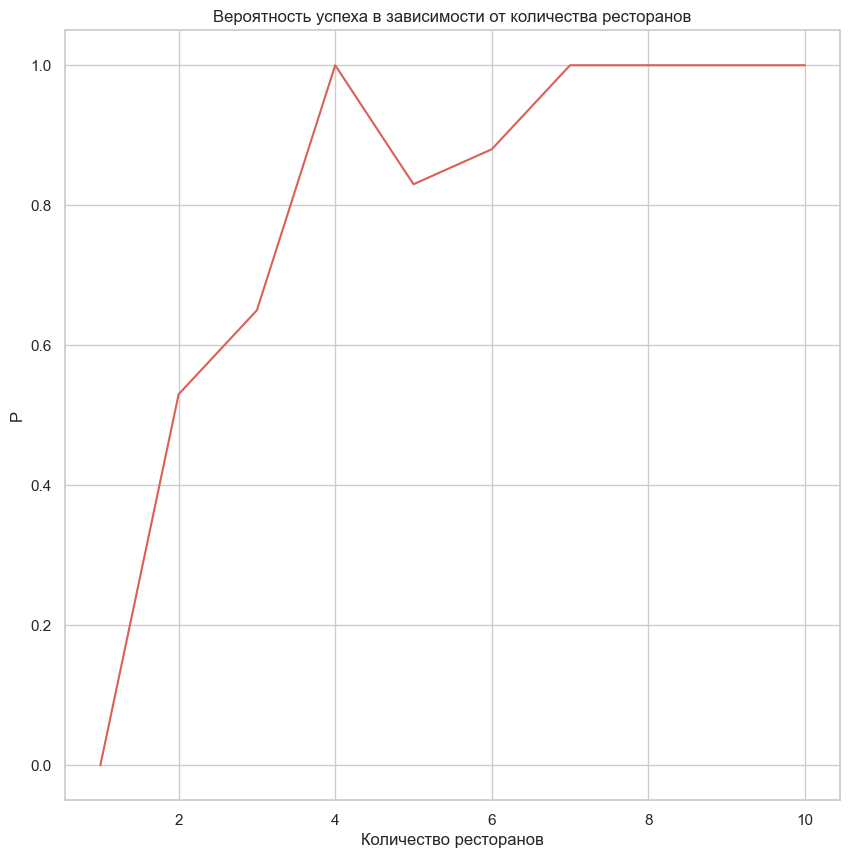

```python
df_old_grouped = df_old.groupby(['city','name']).agg(cnt=('name','count'))
df_close_grouped = df_closed.groupby(['city','name']).agg(cnt=('name','count'))


posible = [0]
iter = [0]
for i in range(1,11):
    iter.append(i)
    posible.append(round((len(df_old_grouped[df_old_grouped['cnt'] == i])

                       / (len(df_old_grouped[df_old_grouped['cnt'] == i])

                     + len(df_close_grouped[df_close_grouped['cnt'] == i]))), 2))

posible.pop(0)
iter.pop(0)

print(posible)

sns.lineplot(x=iter, y=posible)

plt.title('Вероятность успеха в зависимости от количества ресторанов')
plt.xlabel('Количество ресторанов')

plt.ylabel('P')
plt.show()
```

Из графика видно, что рестораны, которые были в единичном экземпляре не удержались на рынке.

Посмотрим среднее количество ресторанов к каждом городе на 2019г.

```python
df_mn =  (df_grouped
             .groupby(['group','city'])
             .agg(mn=('cnt','mean'))
             .sort_values(by=['city'], ascending=False)
             .reset_index()).copy()

df_mn['mn'] = df_mn['mn'].round(0)
df_mn[df_mn['group'] == '2019']
```

|  | group | city | mn |
| --- | --- | --- | --- |
| 1 | 2019 | Portland | 2.0 |
| 3 | 2019 | Miami | 2.0 |
| 5 | 2019 | Las Vegas | 2.0 |
| 7 | 2019 | Indianapolis | 2.0 |
| 9 | 2019 | Columbus | 2.0 |
| 11 | 2019 | Cleveland | 2.0 |
| 13 | 2019 | Cincinnati | 2.0 |
| 15 | 2019 | Birmingham | 2.0 |

Проверим наличие категории "русская кухня" в городах

```python
in_ok = False
df_filtred['russian_kitchen'] = 0
for i in range(len(df_filtred)):
    df_filtred['categories'][i].split(',')
    for j in range(len(df_filtred['categories'][i].split(','))):
        df_filtred['categories'][i].split(',')[j].split(' ')
        for z in range(len(df_filtred['categories'][i].split(',')[j].split(' '))):
            if (df_filtred['categories'][i].split(',')[j].split(' ')[z][0:7].lower() == 'russian'):
                in_ok = True
    if in_ok:
        in_ok = False
        df_filtred.loc[i, 'russian_kitchen'] = 1

df_filtred.groupby('city').agg(cnt=('russian_kitchen','sum'))
```

| city | cnt |
| --- | --- |
| Birmingham | 0 |
| Cincinnati | 0 |
| Cleveland | 0 |
| Columbus | 0 |
| Indianapolis | 0 |
| Las Vegas | 0 |
| Miami | 0 |
| Portland | 0 |

Нарисуем карту, чтобы посмотреть распределение ресторанов на местности.

[figure not shown]

[figure not shown]

[figure not shown]

```python
Portland_map = df_19[(df_19['city'] == 'Portland') & (df_19['group'] == '2019') & (df_19['province'] == 'OR')]
Miami_map = df_19[(df_19['city'] == 'Miami') & (df_19['group'] == '2019') & df_19['province'].isin(states)]
Las_Vegas_map = df_19[(df_19['city'] == 'Las Vegas') & (df_19['group'] == '2019') & df_19['province'].isin(states)]

gdf_portland = gpd.GeoDataFrame(Portland_map,
                                geometry=gpd.points_from_xy(Portland_map.longitude,
                                                            Portland_map.latitude),
                                                            crs="EPSG:4326")

gdf_miami = gpd.GeoDataFrame(Miami_map,
                                geometry=gpd.points_from_xy(Miami_map.longitude,
                                                            Miami_map.latitude),
                                                            crs="EPSG:4326")

gdf_lv = gpd.GeoDataFrame(Las_Vegas_map,
                                geometry=gpd.points_from_xy(Las_Vegas_map.longitude,
                                                            Las_Vegas_map.latitude),
                                                            crs="EPSG:4326")

gdf_portland.crs
portland_wm = gdf_portland.to_crs(epsg=3857)
ax_portland = portland_wm.plot(figsize=(10, 10), alpha=1, edgecolor="black")
plt.title('Portland')
cx.add_basemap(ax_portland)
plt.savefig('Portland.pdf')

gdf_miami.crs
miami_wm = gdf_miami.to_crs(epsg=3857)
ax_miami = miami_wm.plot(figsize=(10, 10), alpha=1, edgecolor="black")
plt.title('Miami')
cx.add_basemap(ax_miami)
plt.savefig('Miami.pdf')

gdf_lv.crs
lv_wm = gdf_lv.to_crs(epsg=3857)
ax_lv = lv_wm.plot(figsize=(10, 10), alpha=1, edgecolor="black")
plt.title('Las Vegas')
cx.add_basemap(ax_lv)
plt.savefig('Las Vegas.pdf')
```

Для корректной работы кода , необходимо в папку с файлом загрузить файлы с данными. Название файлов должно быть в формате: год данных.csv

прим: "2018.csv"

Обязательные поля в данных: ['dateAdded', 'dateUpdated', 'categories', 'city', 'latitude', 'longitude', 'name', 'province']

После обработки код выдает графики, таблицы и карты для дальнейшей аналитики.

Для массштабирования и автоматизации процесса, необходимо сделать следующие доработки:

- Создать три папки: data, done, need check, result. С помощью библиотеки ОС перебирать файлы данных в папке data, сразу проверять их на соответствие формату, на наличие нужных полей для работы и наличия пустых значений в данных. При наличии несоответствий выводить текстовый файл с указанием ошибок и предупреждений. После проверки файл с данными либо добавляется в датафрейм и переносится в папку done, либо просто переносится в папку need check.
- по API сделать автоматичкую загрузку данных о населении, площади, туристическом потоке городом по которым выдется аналитика.
- Блок кода, где ведуться расчеты количества компаний открытых и закрытых, переписать с целью сделать его полностью автоматизированным.
- И для большей глубины аналитики, добавить расчеты по длительности существования компаний на рынке, основываясь на данных из столбцов dateAdded', 'dateUpdated'.